# Predicting Flight Delays at the Pittsburgh Airport

The bagged tree model for which m=p, i.e. 7 in our case explains around 44% of the variation in the Arrival delay.

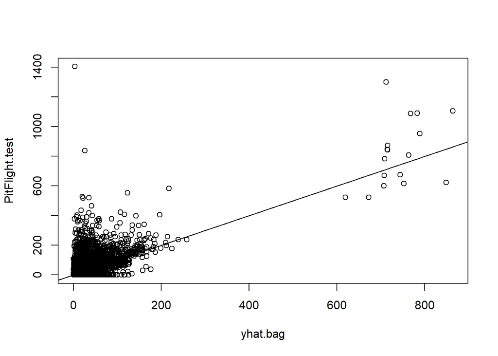

```r
#Bagged trees test error
yhat.bag = predict (bag.PitFlight ,newdata =PIT_2019_ArrivePit_sub.df [-train ,])
PitFlight.test <-PIT_2019_ArrivePit_sub.df[-train,"ArrDelayNew"]
plot(yhat.bag , PitFlight.test)
abline (0,1)
```

```r
mean(( yhat.bag -PitFlight.test)^2)
```

```
## [1] 976.0602
```

The mean squared test error for bagged trees is 976.0602298, which is higher than the train error. However, the MSE is much lower when compared to the linear regression model.

```r
# Random forest

rf.PitFlight =randomForest(ArrDelayNew ∼.,data=PIT_2019_ArrivePit_sub.df ,subset =train , mtry=3, importance =TRUE)
# Random forest test error
yhat.rf = predict (rf.PitFlight ,newdata =PIT_2019_ArrivePit_sub.df [-train ,])
mean(( yhat.rf - PitFlight.test)^2)
```

```
## [1] 1058.657
```

```r
importance(rf.PitFlight)
```

```
##             %IncMSE IncNodePurity
## Month      33.24019       2760712
## DayOfMonth 14.80367       4750552
## DayOfWeek  10.40277       2032052
## Carrier    36.85707       2879886
## OriginCity 42.44094       3437944
## AdjArrTime 64.94868      14824667
## Distance   29.86106       1324988
```

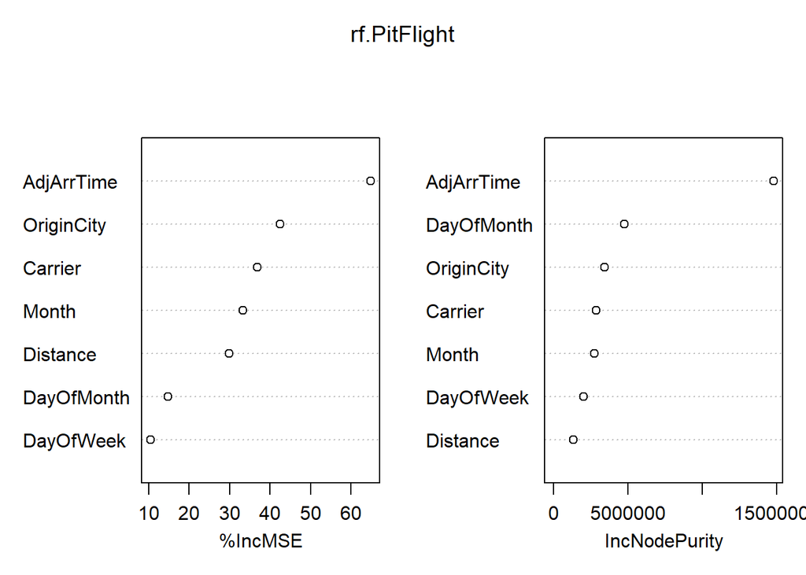

```r
varImpPlot (rf.PitFlight)
```

**Interpretation of Random Forest:**

The mean squared error for the test dataset is 1058.6568816, which is slightly more than the bagged trees. Again, though, this is much lesser than the linear regression model. The variable which explains the variation the most is the Adjusted Arrival Time (AdjArrTime), followed by Origin City, Carrier, Month, and Distance.

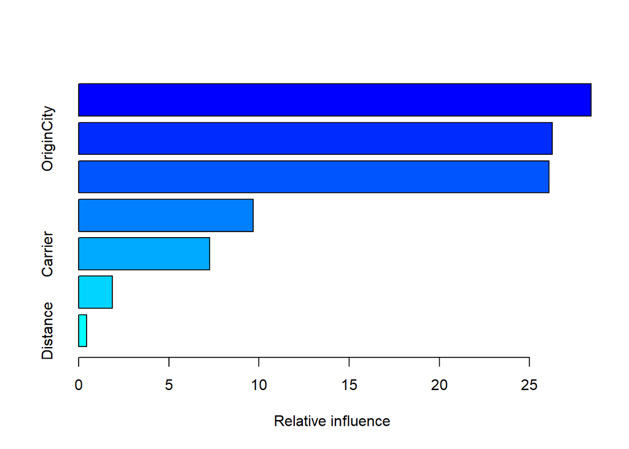

```
##                   var    rel.inf
## AdjArrTime AdjArrTime 28.4133661
## OriginCity OriginCity 26.2507622
## DayOfMonth DayOfMonth 26.0822952
## Month           Month  9.6759860
## Carrier       Carrier  7.2637124
## DayOfWeek   DayOfWeek  1.8683523
## Distance     Distance  0.4455258
```

```r
# Boosting
boost.PitFlight =gbm(ArrDelayNew∼.,data=PIT_2019_ArrivePit_sub.df [train ,], distribution=
"gaussian",n.trees =5000 , interaction.depth =4)
summary(boost.PitFlight)
```

```r
yhat.boost=predict (boost.PitFlight ,newdata =PIT_2019_ArrivePit_sub.df [-train ,],
n.trees =5000)
mean(( yhat.boost -PitFlight.test)^2)
```

```
## [1] 1096.77
```

```r
boost.PitFlight =gbm(ArrDelayNew ∼.,data=PIT_2019_ArrivePit_sub.df[train ,], distribution= "gaussian", n.trees =5000, interaction.depth =4, shrinkage =0.2, verbose =F)
yhat.boost = predict (boost.PitFlight ,newdata =PIT_2019_ArrivePit_sub.df[-train ,],
n.trees =5000)
mean(( yhat.boost - PitFlight.test)^2)
```

```
## [1] 1143.284
```

**Interpretation:**

The mean squared error produced from this approach is 1143.2844264. Again, this is similar to what we obtained from the Random Forest method.

**GLM With Forward Selection:**

```r
PIT_2019_ArrivePit.df <- select(PIT_2019_ArrivePit.df,-c(DestCity))
glm.fit = glm(ArrDelayNew~., data = PIT_2019_ArrivePit.df, subset=train)

kable(data.frame(summary(glm.fit)$coef[summary(glm.fit)$coef[,4]<= 0.05, 1:4]))
```

|  | Estimate | Std..Error | t.value | Pr…t.. |
| --- | --- | --- | --- | --- |
| MonthMar | 0 | 0 | 4.858286e+01 | 0.0000000 |
| MonthApr | 0 | 0 | -2.473660e+00 | 0.0134107 |
| MonthJuly | 0 | 0 | 3.600361e+00 | 0.0003212 |
| MonthOct | 0 | 0 | 2.803265e+00 | 0.0050807 |
| MonthDec | 0 | 0 | -2.188617e+00 | 0.0286765 |
| DayOfMonth2 | 0 | 0 | -2.012801e+00 | 0.0441958 |
| DayOfMonth3 | 0 | 0 | -5.705923e+00 | 0.0000000 |
| DayOfMonth13 | 0 | 0 | -3.855991e+00 | 0.0001169 |
| DayOfMonth20 | 0 | 0 | -3.433288e+00 | 0.0006018 |
| DayOfMonth21 | 0 | 0 | -2.514630e+00 | 0.0119507 |
| DayOfMonth23 | 0 | 0 | -3.300959e+00 | 0.0009711 |
| DayOfMonth26 | 0 | 0 | 2.018211e+00 | 0.0436292 |
| DayOfWeekThur | 0 | 0 | -2.192275e+00 | 0.0284113 |
| CarrierJetBlue | 0 | 0 | -2.269988e+00 | 0.0232560 |
| DepDelayNew | 0 | 0 | 3.196958e+00 | 0.0013986 |
| DepTimeGroupAfternoon | 0 | 0 | -2.191492e+00 | 0.0284679 |
| DepTimeGroupEvening | 0 | 0 | -2.813378e+00 | 0.0049239 |
| DepTimeGroupNight | 0 | 0 | -3.196658e+00 | 0.0014000 |
| AdjDepTime | 0 | 0 | 2.376899e+00 | 0.0175010 |
| CarrierDelay | 1 | 0 | 1.233542e+15 | 0.0000000 |
| WeatherDelay | 1 | 0 | 1.205698e+15 | 0.0000000 |
| NasDelay | 1 | 0 | 1.479244e+15 | 0.0000000 |
| SecurityDelay | 1 | 0 | 3.697415e+14 | 0.0000000 |
| LateAircraftDelay | 1 | 0 | 1.221405e+15 | 0.0000000 |
| ArrDelayNewLog | 0 | 0 | 3.392961e+00 | 0.0006975 |

```r
summary(glm.fit)
```

```
##
## Call:
## glm(formula = ArrDelayNew ~ ., data = PIT_2019_ArrivePit.df,
##     subset = train)
##
## Deviance Residuals:
##        Min          1Q      Median          3Q         Max
## -2.665e-12   1.066e-14   1.386e-13   2.700e-13   1.364e-12
##
## Coefficients: (1 not defined because of singularities)
##                                            Estimate Std. Error    t value
## (Intercept)                              -2.396e-12  2.365e-12 -1.013e+00
## MonthFeb                                  2.204e-14  5.095e-14  4.330e-01
## MonthMar                                  2.509e-12  5.165e-14  4.858e+01
## MonthApr                                 -1.208e-13  4.882e-14 -2.474e+00
## MonthMay                                 -5.366e-14  4.693e-14 -1.144e+00
## MonthJune                                 1.608e-14  4.463e-14  3.600e-01
## MonthJuly                                 1.650e-13  4.582e-14  3.600e+00
## MonthAug                                  4.682e-14  4.704e-14  9.950e-01
## MonthSep                                  9.794e-14  5.373e-14  1.823e+00
## MonthOct                                  1.465e-13  5.228e-14  2.803e+00
## MonthNov                                 -3.059e-14  5.540e-14 -5.520e-01
## MonthDec                                 -1.055e-13  4.821e-14 -2.189e+00
## DayOfMonth2                              -1.325e-13  6.582e-14 -2.013e+00
## DayOfMonth3                              -4.204e-13  7.369e-14 -5.706e+00
## DayOfMonth4                               3.691e-14  7.876e-14  4.690e-01
## DayOfMonth5                              -9.511e-14  8.089e-14 -1.176e+00
## DayOfMonth6                               1.907e-14  7.480e-14  2.550e-01
## DayOfMonth7                              -5.793e-14  7.212e-14 -8.030e-01
## DayOfMonth8                               7.440e-15  6.767e-14  1.100e-01
## DayOfMonth9                              -1.396e-13  7.542e-14 -1.851e+00
## DayOfMonth10                              9.053e-14  7.021e-14  1.289e+00
## DayOfMonth11                             -4.011e-14  6.825e-14 -5.880e-01
## DayOfMonth12                             -5.115e-14  7.015e-14 -7.290e-01
## DayOfMonth13                             -2.688e-13  6.970e-14 -3.856e+00
## DayOfMonth14                             -2.708e-14  7.050e-14 -3.840e-01
## DayOfMonth15                             -4.271e-14  7.110e-14 -6.010e-01
## DayOfMonth16                              4.693e-14  7.661e-14  6.130e-01
## DayOfMonth17                             -3.474e-14  6.921e-14 -5.020e-01
## DayOfMonth18                              1.005e-13  6.561e-14  1.532e+00
```

[output cut: 216 more lines]

```
## NasDelay                                      < 2e-16 ***
## SecurityDelay                                 < 2e-16 ***
## LateAircraftDelay                             < 2e-16 ***
## ArrDelayNewLog                               0.000697 ***
## ---
## Signif. codes:  0 '***' 0.001 '**' 0.01 '*' 0.05 '.' 0.1 ' ' 1
##
## (Dispersion parameter for gaussian family taken to be 4.411255e-25)
##
##     Null deviance: 2.0368e+07  on 4570  degrees of freedom
## Residual deviance: 1.9621e-21  on 4448  degrees of freedom
##   (20141 observations deleted due to missingness)
## AIC: -243249
##
## Number of Fisher Scoring iterations: 1
```

```r
set.seed(1)
train <- sample(1:nrow(PIT_2019_ArrivePit.df), nrow(PIT_2019_ArrivePit.df)/2)
test <- PIT_2019_ArrivePit.df$ArrDelayNew[-train]

#Arrival Delay
fwd.subset1 <- regsubsets(ArrDelayNew~., data = PIT_2019_ArrivePit.df, subset=train, nbest = 1, nvmax = 8, method = "forward", really.big = TRUE)
```

```
## Reordering variables and trying again:
```

```r
kable(coef(fwd.subset1, id = 2))
```

|  | x |
| --- | --- |
| (Intercept) | 64.860251 |
| ArrTimeGroupNight | 2.421183 |
| OriginCityPittsburgh, PA | 0.000000 |

```r
kable(coef(fwd.subset1, id = 4))
```

|  | x |
| --- | --- |
| (Intercept) | 65.040532 |
| ArrTimeGroupNight | 2.240902 |
| CarrierRepublic | 0.000000 |
| OriginCityPittsburgh, PA | 0.000000 |
| OriginCitySeattle, WA | -22.790532 |

```r
kable(coef(fwd.subset1, id = 8))
```

|  | x |
| --- | --- |
| (Intercept) | -245.168556 |
| CarrierUnited | -1.232863 |
| ArrTimeGroupNight | -2.766987 |
| ArrDelayNewLog | 80.702445 |
| CarrierRepublic | 0.000000 |
| OriginCityPittsburgh, PA | 0.000000 |
| OriginCitySan Diego, CA | 0.000000 |
| OriginCitySan Juan, PR | 0.000000 |
| OriginCitySeattle, WA | 1.563090 |

**Interpretation:**